# Bellabeat Project

Joaquin Moya

2024-12-29

# Description of the company

Bellabeat is a high-tech company founded by Urška Sršen and Sando Mur which is involved in the manufacture of health-focused smart products using their artistic background to develop beautifully designed technology that informs and inspires women around the world.

List of their products:

- Bellabeat app: Provides users data related to their activity, sleep, stress, menstrual cycle, and mindfulness habits.
- Leaf: Bellabeat’s classic wellness tracker can be worn as a bracelet, necklace, or clip. The Leaf tracker connects to the Bellabeat app to track activity, sleep, and stress.
- Time: This wellness watch combines the timeless look of a classic timepiece with smart technology to track user activity, sleep, and stress. The Time watch connects to the Bellabeat app to provide you with insights into your daily wellness.
- Spring: This is a water bottle that tracks daily water intake using smart technology to ensure that you are appropriately hydrated throughout the day. The Spring bottle connects to the Bellabeat app to track your hydration levels.
- Bellabeat membership: Gives users 24/7 access to fully personalized guidance on nutrition, activity, sleep, health and beauty, and mindfulness based on their lifestyle and goals.

# Data Analysis Business Task

Being able to provide the following:

- A clear summary of the business task
- A description of all data sources used
- Documentation of any cleaning or manipulation of data
- A summary of your analysis
- Supporting visualizations and key findings
- Top high-level content recommendations based on your analysis

### Business Statement (Ask)

Conduct a thorough data analysis to uncover key patterns and trends in Bellabeat device usage. This analysis should aim to identify:

- User behavior: Analyze activity levels across different demographics, identify peak usage times, and understand how usage patterns vary across different product lines.
- Product performance: Evaluate key metrics like step count, sleep duration, heart rate variability, and app engagement. Identify areas for product improvement and new feature development.
- Customer segmentation: Identify distinct user segments based on their usage patterns, demographics, and fitness goals. This will enable targeted marketing campaigns and personalized user experiences.

By uncovering these hidden insights, Bellabeat can develop more effective marketing strategies, tailor product offerings to specific user needs, and ultimately enhance customer satisfaction and brand loyalty.”

## Data Sourcers and Preparation (Prepare)

We are going to use a public data that explores smart device users’ daily habits(CC0: Public Domain, dataset made available through [Mobius](https://www.kaggle.com/arashnic)): This Kaggle data set contains personal fitness tracker from thirty fitbit users. Thirty eligible Fitbit users consented to the submission of personal tracker data, including minute-level output for physical activity, heart rate, and sleep monitoring. It includes information about daily activity, steps, and heart rate that can be used to explore users’ habits.

The dataset can be found in the following -> [link](https://www.kaggle.com/datasets/arashnic/fitbit/data)

## Documentation of any cleaning or manipulation of data (Process)

The next steps are going to be focused on:

- Install the necessary libraries for the analysis
- Load the required data sets
- EDA (Exploratory Data Analysis)
- Data Cleaning

```r
library(tidyverse)
```

```r
library(ggplot2)
library(lubridate)
library(readr)
library(janitor)
library(ggbeeswarm)
library(ggridges)
library(data.table)
heartrate_seconds<- read_csv("C:/Users/Moi/Desktop/Certificados/Google Certificate/Capstones Projects/Bellabeat Proyect/Fitabase Data 3.12.16-4.11.16/heartrate_seconds_merged.csv")
View(heartrate_seconds)

hourlyCalories<- read_csv("C:/Users/Moi/Desktop/Certificados/Google Certificate/Capstones Projects/Bellabeat Proyect/Fitabase Data 3.12.16-4.11.16/hourlyCalories_merged.csv")
View(hourlyCalories)

hourlySteps<- read_csv("C:/Users/Moi/Desktop/Certificados/Google Certificate/Capstones Projects/Bellabeat Proyect/Fitabase Data 3.12.16-4.11.16/hourlySteps_merged.csv")
View(hourlySteps)

sleepDay<- read_csv("C:/Users/Moi/Desktop/Certificados/Google Certificate/Capstones Projects/Bellabeat Proyect/Fitabase Data 4.12.16-5.12.16/sleepDay_merged.csv")
View(sleepDay)
```

### Exploratory Data Analysis

```r
str(heartrate_seconds)
```

```
## spc_tbl_ [1,154,681 × 3] (S3: spec_tbl_df/tbl_df/tbl/data.frame)
##  $ Id   : num [1:1154681] 2.02e+09 2.02e+09 2.02e+09 2.02e+09 2.02e+09 ...
##  $ Time : chr [1:1154681] "4/1/2016 7:54:00 AM" "4/1/2016 7:54:05 AM" "4/1/2016 7:54:10 AM" "4/1/2016 7:54:15 AM" ...
##  $ Value: num [1:1154681] 93 91 96 98 100 101 104 105 102 106 ...
##  - attr(*, "spec")=
##   .. cols(
##   ..   Id = col_double(),
##   ..   Time = col_character(),
##   ..   Value = col_double()
##   .. )
##  - attr(*, "problems")=<externalptr>
```

```r
summary(heartrate_seconds)
```

```
##        Id                Time               Value
##  Min.   :2.022e+09   Length:1154681     Min.   : 36.00
##  1st Qu.:4.020e+09   Class :character   1st Qu.: 66.00
##  Median :5.554e+09   Mode  :character   Median : 77.00
##  Mean   :5.352e+09                      Mean   : 79.76
##  3rd Qu.:6.962e+09                      3rd Qu.: 90.00
##  Max.   :8.878e+09                      Max.   :185.00
```

```r
head(heartrate_seconds)
```

```
## # A tibble: 6 × 3
##           Id Time                Value
##        <dbl> <chr>               <dbl>
## 1 2022484408 4/1/2016 7:54:00 AM    93
## 2 2022484408 4/1/2016 7:54:05 AM    91
## 3 2022484408 4/1/2016 7:54:10 AM    96
## 4 2022484408 4/1/2016 7:54:15 AM    98
## 5 2022484408 4/1/2016 7:54:20 AM   100
## 6 2022484408 4/1/2016 7:54:25 AM   101
```

```r
str(hourlyCalories)
```

```
## spc_tbl_ [24,084 × 3] (S3: spec_tbl_df/tbl_df/tbl/data.frame)
##  $ Id          : num [1:24084] 1.5e+09 1.5e+09 1.5e+09 1.5e+09 1.5e+09 ...
##  $ ActivityHour: chr [1:24084] "3/12/2016 12:00:00 AM" "3/12/2016 1:00:00 AM" "3/12/2016 2:00:00 AM" "3/12/2016 3:00:00 AM" ...
##  $ Calories    : num [1:24084] 48 48 48 48 48 48 48 48 48 49 ...
##  - attr(*, "spec")=
##   .. cols(
##   ..   Id = col_double(),
##   ..   ActivityHour = col_character(),
##   ..   Calories = col_double()
##   .. )
##  - attr(*, "problems")=<externalptr>
```

```r
summary(hourlyCalories)
```

```
##        Id            ActivityHour          Calories
##  Min.   :1.504e+09   Length:24084       Min.   : 42.00
##  1st Qu.:2.347e+09   Class :character   1st Qu.: 61.00
##  Median :4.559e+09   Mode  :character   Median : 77.00
##  Mean   :4.889e+09                      Mean   : 94.27
##  3rd Qu.:6.962e+09                      3rd Qu.:104.00
##  Max.   :8.878e+09                      Max.   :933.00
```

```r
head(hourlyCalories)
```

```
## # A tibble: 6 × 3
##           Id ActivityHour          Calories
##        <dbl> <chr>                    <dbl>
## 1 1503960366 3/12/2016 12:00:00 AM       48
## 2 1503960366 3/12/2016 1:00:00 AM        48
## 3 1503960366 3/12/2016 2:00:00 AM        48
## 4 1503960366 3/12/2016 3:00:00 AM        48
## 5 1503960366 3/12/2016 4:00:00 AM        48
## 6 1503960366 3/12/2016 5:00:00 AM        48
```

```r
str(hourlySteps)
```

```
## spc_tbl_ [24,084 × 3] (S3: spec_tbl_df/tbl_df/tbl/data.frame)
##  $ Id          : num [1:24084] 1.5e+09 1.5e+09 1.5e+09 1.5e+09 1.5e+09 ...
##  $ ActivityHour: chr [1:24084] "3/12/2016 12:00:00 AM" "3/12/2016 1:00:00 AM" "3/12/2016 2:00:00 AM" "3/12/2016 3:00:00 AM" ...
##  $ StepTotal   : num [1:24084] 0 0 0 0 0 0 0 0 0 8 ...
##  - attr(*, "spec")=
##   .. cols(
##   ..   Id = col_double(),
##   ..   ActivityHour = col_character(),
##   ..   StepTotal = col_double()
##   .. )
##  - attr(*, "problems")=<externalptr>
```

```r
summary(hourlySteps)
```

```
##        Id            ActivityHour         StepTotal
##  Min.   :1.504e+09   Length:24084       Min.   :    0.0
##  1st Qu.:2.347e+09   Class :character   1st Qu.:    0.0
##  Median :4.559e+09   Mode  :character   Median :   10.0
##  Mean   :4.889e+09                      Mean   :  286.2
##  3rd Qu.:6.962e+09                      3rd Qu.:  289.0
##  Max.   :8.878e+09                      Max.   :10565.0
```

```r
head(hourlySteps)
```

```
## # A tibble: 6 × 3
##           Id ActivityHour          StepTotal
##        <dbl> <chr>                     <dbl>
## 1 1503960366 3/12/2016 12:00:00 AM         0
## 2 1503960366 3/12/2016 1:00:00 AM          0
## 3 1503960366 3/12/2016 2:00:00 AM          0
## 4 1503960366 3/12/2016 3:00:00 AM          0
## 5 1503960366 3/12/2016 4:00:00 AM          0
## 6 1503960366 3/12/2016 5:00:00 AM          0
```

```r
str(sleepDay)
```

```
## spc_tbl_ [413 × 5] (S3: spec_tbl_df/tbl_df/tbl/data.frame)
##  $ Id                : num [1:413] 1.5e+09 1.5e+09 1.5e+09 1.5e+09 1.5e+09 ...
##  $ SleepDay          : chr [1:413] "4/12/2016 12:00:00 AM" "4/13/2016 12:00:00 AM" "4/15/2016 12:00:00 AM" "4/16/2016 12:00:00 AM" ...
##  $ TotalSleepRecords : num [1:413] 1 2 1 2 1 1 1 1 1 1 ...
##  $ TotalMinutesAsleep: num [1:413] 327 384 412 340 700 304 360 325 361 430 ...
##  $ TotalTimeInBed    : num [1:413] 346 407 442 367 712 320 377 364 384 449 ...
##  - attr(*, "spec")=
##   .. cols(
##   ..   Id = col_double(),
##   ..   SleepDay = col_character(),
##   ..   TotalSleepRecords = col_double(),
##   ..   TotalMinutesAsleep = col_double(),
##   ..   TotalTimeInBed = col_double()
##   .. )
##  - attr(*, "problems")=<externalptr>
```

```r
summary(sleepDay)
```

```
##        Id              SleepDay         TotalSleepRecords TotalMinutesAsleep
##  Min.   :1.504e+09   Length:413         Min.   :1.000     Min.   : 58.0
##  1st Qu.:3.977e+09   Class :character   1st Qu.:1.000     1st Qu.:361.0
##  Median :4.703e+09   Mode  :character   Median :1.000     Median :433.0
##  Mean   :5.001e+09                      Mean   :1.119     Mean   :419.5
##  3rd Qu.:6.962e+09                      3rd Qu.:1.000     3rd Qu.:490.0
##  Max.   :8.792e+09                      Max.   :3.000     Max.   :796.0
##  TotalTimeInBed
##  Min.   : 61.0
##  1st Qu.:403.0
##  Median :463.0
##  Mean   :458.6
##  3rd Qu.:526.0
##  Max.   :961.0
```

```r
head(sleepDay)
```

```
## # A tibble: 6 × 5
##           Id SleepDay        TotalSleepRecords TotalMinutesAsleep TotalTimeInBed
##        <dbl> <chr>                       <dbl>              <dbl>          <dbl>
## 1 1503960366 4/12/2016 12:0…                 1                327            346
## 2 1503960366 4/13/2016 12:0…                 2                384            407
## 3 1503960366 4/15/2016 12:0…                 1                412            442
## 4 1503960366 4/16/2016 12:0…                 2                340            367
## 5 1503960366 4/17/2016 12:0…                 1                700            712
## 6 1503960366 4/19/2016 12:0…                 1                304            320
```

- As a quick observation, we need to change the format of the dates from chr to date format

Taking a look if we found some NA’s

```r
colSums(is.na(heartrate_seconds))
```

```
##    Id  Time Value
##     0     0     0
```

```r
colSums(is.na(hourlyCalories))
```

```
##           Id ActivityHour     Calories
##            0            0            0
```

```r
colSums(is.na(hourlySteps))
```

```
##           Id ActivityHour    StepTotal
##            0            0            0
```

```r
colSums(is.na(sleepDay))
```

```
##                 Id           SleepDay  TotalSleepRecords TotalMinutesAsleep
##                  0                  0                  0                  0
##     TotalTimeInBed
##                  0
```

- No NA’s

Let’s review if there are any duplicated values

```r
summary(duplicated(heartrate_seconds))
```

```
##    Mode   FALSE
## logical 1154681
```

```r
summary(duplicated(hourlyCalories))
```

```
##    Mode   FALSE
## logical   24084
```

```r
summary(duplicated(hourlySteps))
```

```
##    Mode   FALSE
## logical   24084
```

```r
summary(duplicated((sleepDay)))
```

```
##    Mode   FALSE    TRUE
## logical     410       3
```

- We found 3 duplicated rows in the sleepDay dataset
- Lets remove them

### Data Cleaning

```r
sleepDay<-sleepDay[!duplicated(sleepDay),]
```

Knowing that the Calories and Steps datasets have the same number of rows and columns, we are going to merge both of them considering the Id and the ActivityHour which are the same

```r
hourly_calories_steps<-merge(hourlyCalories, hourlySteps,by=c("Id","ActivityHour"),all=TRUE)
```

We are going to change the dates from chr to date format

```r
heartrate_seconds$Time <- mdy_hms(heartrate_seconds$Time)
hourlyCalories$ActivityHour<-mdy_hms(hourlyCalories$ActivityHour)
hourlySteps$ActivityHour<-mdy_hms(hourlySteps$ActivityHour)
hourly_calories_steps$ActivityHour<-mdy_hms(hourly_calories_steps$ActivityHour)
sleepDay$SleepDay<-as.Date(sleepDay$SleepDay, format = '%m/%d/%Y')
```

Now lets add weekdays to each data set for a better daily analysis

```r
sleepDay$Day_week<-weekdays(sleepDay$SleepDay)
hourlyCalories$Day_week<-weekdays(hourlyCalories$ActivityHour)
hourlySteps$Day_week<-weekdays(hourlySteps$ActivityHour)
hourly_calories_steps$Day_week<-weekdays(hourly_calories_steps$ActivityHour)
```

For a more accurate analysis with the heart rate, steps and calories data set, we are going to divide every hour, minute and second just in case

```r
heartrate_seconds$Hour<-hour(heartrate_seconds$Time)
heartrate_seconds$Minute<-minute(heartrate_seconds$Time)
heartrate_seconds$Seconds<-second(heartrate_seconds$Time)
hourlyCalories$Hour<-hour(hourlyCalories$ActivityHour)
hourlySteps$Hour<-hour(hourlySteps$ActivityHour)
hourly_calories_steps$Hour<-hour(hourly_calories_steps$ActivityHour)
```

## Summary of the data (Analysis)

### Heart Rates

We are going to measure the heart rate by every hour to analyse during which period of time, the heart is more active

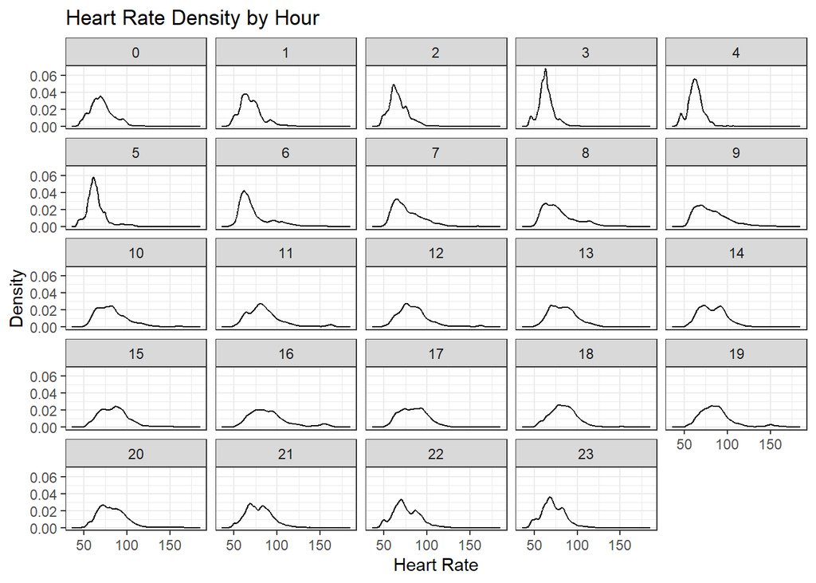

```r
ggplot(heartrate_seconds, aes(x = Value)) +
  geom_density() +
  facet_wrap(~ Hour) +
  labs(x = "Heart Rate", y = "Density", title = "Heart Rate Density by Hour") +
  theme_bw()
```

The following graphs depict periods of lower heart rate variability, typically between 2:00 AM and 6:00 AM. Lower heart rate variability during these hours often indicates deeper sleep and a more relaxed state, as the heart’s rhythm remains relatively consistent. By the other hand, increased heart rate variability observed between 10:00 AM and 8:00 PM likely reflects heightened activity levels during the day. The flatter appearance of the graphs during these hours suggests a wider range of heart rates, indicative of increased physiological activity and engagement in daily routines.”

### Sleeping

The sleepDay dataset is going to be distributed by the quality of sleep This division is going to be distributed by the number of minutes

- 0-240 minutes<-4 hours (Bad sleeper)
- 0-420 minutes<-7 hours (Regular sleeper)
- 0-500 minutes<-8.3 hours (Good sleeper)
- +500 minutes<- Oversleeping

```r
sleepDay$sleep_quality <- cut(sleepDay$TotalMinutesAsleep,
                              breaks = c(-Inf, 240, 420, 500, Inf),
                              labels = c("Bad sleeper", "Regular sleeper", "Good sleeper", "Oversleeping"))
```

We are going to ilustrate the percentage distribution for better understanding of the records

```r
sleep_quantity_count<-sleepDay %>%
  group_by(sleep_quality) %>%
  summarize(count_sleepers = sum(sleep_quality %in%
                                   c("Bad sleeper", "Regular sleeper",'Good sleeper','Oversleeping')))

total_sleepers<-sum(sleep_quantity_count$count_sleepers)

sleep_quantity_counts_percentage <- sleep_quantity_count %>%
  mutate(percentage = (count_sleepers / total_sleepers) * 100)
```

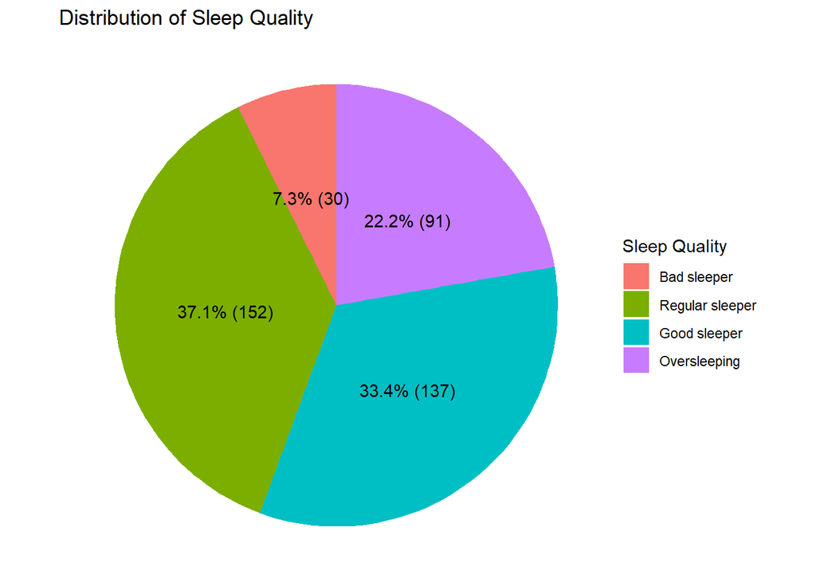

```r
ggplot(sleep_quantity_counts_percentage, aes(x = "", y = percentage, fill = sleep_quality)) +
  geom_bar(stat = "identity", width = 1) +
  coord_polar(theta = "y") +
  labs(title = "Distribution of Sleep Quality", fill = "Sleep Quality") +
  theme_void() +
  geom_text(aes(label = paste0(round(percentage, 1), "% (", count_sleepers, ")")),
            position = position_stack(vjust = 0.5))
```

Sleep quality box plot

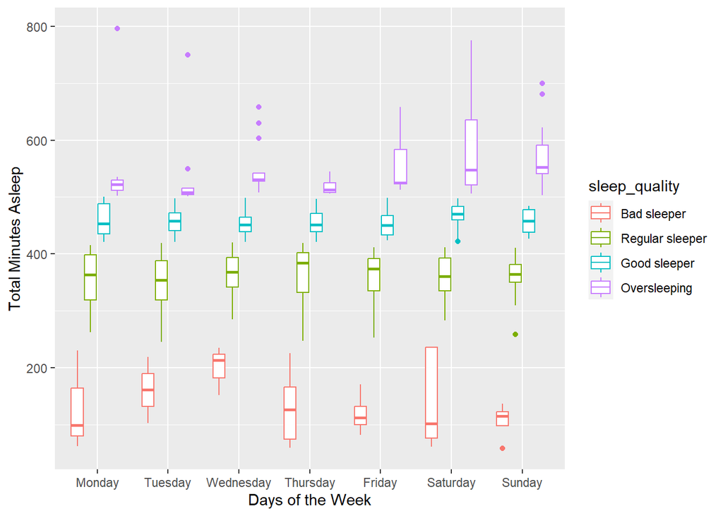

```r
ggplot(sleepDay, aes(x = factor(Day_week,
levels = c("Monday", "Tuesday", "Wednesday", "Thursday", "Friday", "Saturday", "Sunday")),
y = TotalMinutesAsleep,
color = sleep_quality)) +
geom_boxplot()+labs(x = "Days of the Week", y = "Total Minutes Asleep")
```

### Calories and Steps

Now we are going to divide the types of users based on their calorie expenditure to determine their activity levels. The more calories they are burning, the more involved the body is in an energetic state

- 0-100 calories (LowActivity)
- 100-200 calories(RegularActivity)
- 200-400 calories(HighlyActivity)
- +400 calories(VeryActive)

```r
hourly_calories_steps$type_of_user<-cut(hourly_calories_steps$Calories,
breaks = c(-Inf, 100, 200, 400, Inf),
labels = c("LowActivity", "RegularActivity", "HighlyActive", "VeryActive"))
```

We are going to do another percentage distribution for better understanding of the records

```r
users_quantity<-hourly_calories_steps %>%
group_by(type_of_user) %>%
summarize(count_users = sum(type_of_user %in%
c("LowActivity", "RegularActivity",'HighlyActive','VeryActive')))

total_users<-sum(users_quantity$count_users)


users_quantity_counts_percentage <- users_quantity %>%
  mutate(percentage = (count_users / total_users) * 100)
```

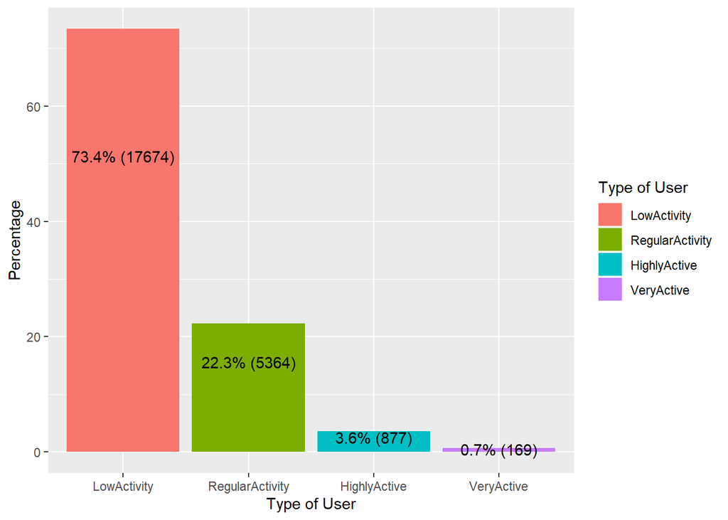

```r
ggplot(users_quantity_counts_percentage, aes(x = type_of_user, y = percentage, fill = type_of_user)) +
  geom_col() +
  labs(x = "Type of User", y = "Percentage", fill = "Type of User") +
  geom_text(aes(label = paste0(round(percentage, 1), "% (", count_users, ")")),
  position = position_stack(vjust = 0.7))
```

#### Correlation of steps and calories

```r
cor(hourly_calories_steps$Calories,hourly_calories_steps$StepTotal)
```

```
## [1] 0.8257203
```

- The correlation suggests into a highly positive relation between steps and calories

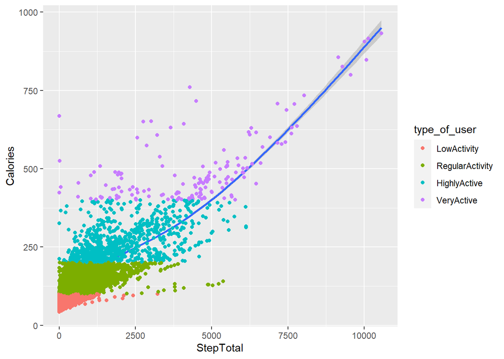

```r
ggplot(hourly_calories_steps)+geom_smooth(mapping = aes(x=StepTotal,
y=Calories))+geom_point(mapping=aes(x=StepTotal, y=Calories, color=type_of_user))
```

- The trend is completely positive and the types of users are more concentrated in the LowActivity and RegularActivity group. By the other hand, there is a wider distribution with the purple points which are from the group of the VeryActive users. As a conclusion, we can say that most of the people tend to be more less proactive as expected

#### Distribution of calories per hour

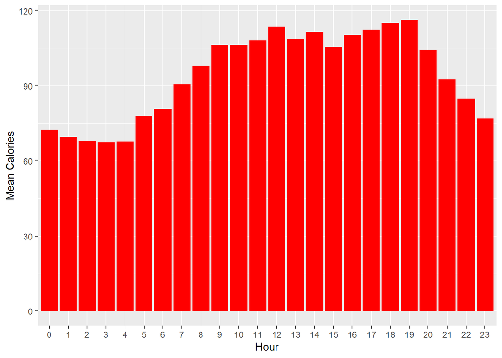

```r
ggplot(hourly_calories_steps, aes(x = factor(Hour))) +
  stat_summary(fun = "mean", geom = "bar", aes(y = Calories), fill='red') +
  labs(x = "Hour", y = "Mean Calories")
```

- People tend to be more active at 12:00PM and 19:00PM. Hours where are known as lunch time or clocking out hours from their jobs aimed to do one last extra activity for the day.

#### Distribution of steps per hour

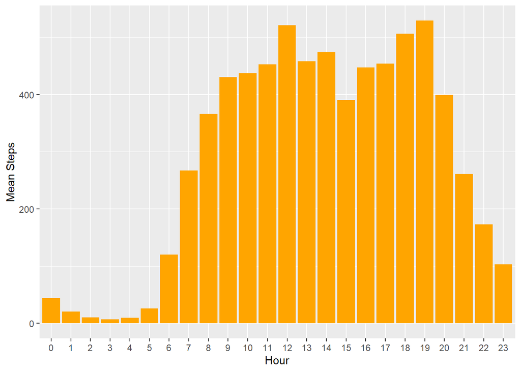

```r
ggplot(hourly_calories_steps, aes(x = factor(Hour))) +
  stat_summary(fun = "mean", geom = "bar", aes(y = StepTotal), fill='orange') +
  labs(x = "Hour", y = "Mean Steps")
```

- The same thing happens with the steps and it was an expected result considering the correlation we just calculated

#### Distribution of calories and steps by day of the week and type of user

```r
calories <- hourly_calories_steps %>%
  group_by(Day_week, type_of_user)%>%
  summarise(mean_calories = mean(Calories))
steps <- hourly_calories_steps %>%
  group_by(Day_week, type_of_user)%>%
  summarise(mean_steps = mean(StepTotal))
```

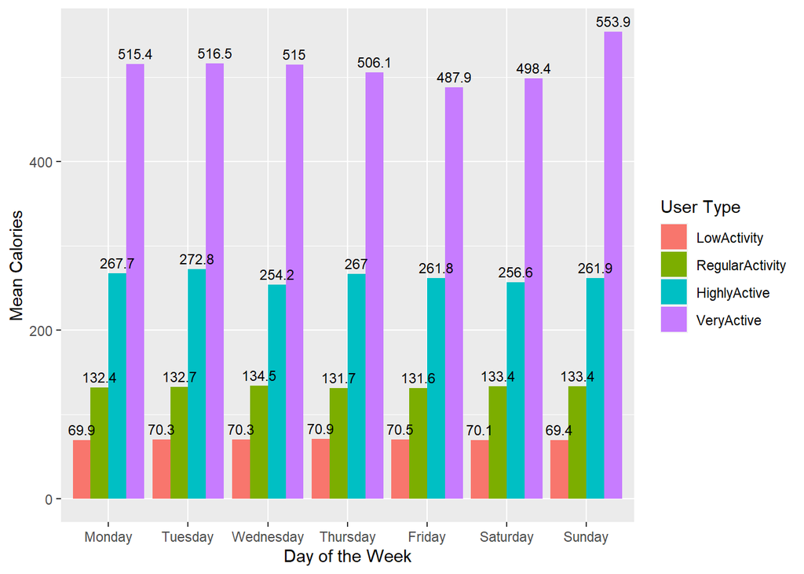

```r
ggplot(calories, aes(x = factor(Day_week,levels = c("Monday", "Tuesday",
"Wednesday", "Thursday", "Friday", "Saturday", "Sunday")), y = mean_calories,
fill = type_of_user)) + geom_col(position = "dodge") +
labs(x = "Day of the Week", y = "Mean Calories", fill = "User Type")+geom_text(aes(label = round(mean_calories, 1)),
position = position_dodge(width = 0.9), vjust = -0.5, size = 3)
```

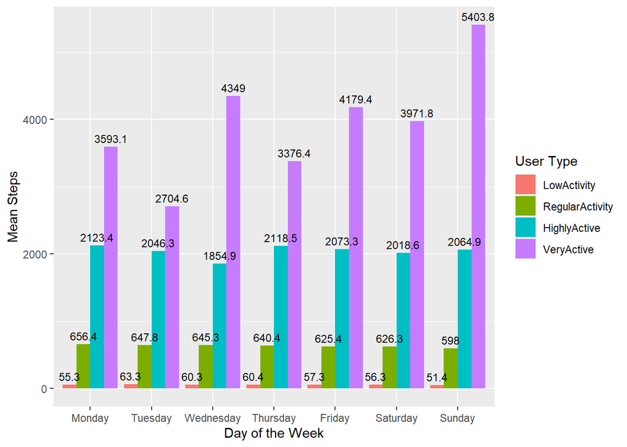

```r
ggplot(steps, aes(x = factor(Day_week,levels = c("Monday", "Tuesday",
"Wednesday", "Thursday", "Friday", "Saturday", "Sunday")), y = mean_steps,
fill = type_of_user)) + geom_col(position = "dodge") +
labs(x = "Day of the Week", y = "Mean Steps", fill = "User Type")+geom_text(aes(label = round(mean_steps, 1)),
position = position_dodge(width = 0.9), vjust = -0.5, size = 3)
```

- Finally we wanted to see which day was the most productive day for physical activity for the users. The graphs represents how Sunday is the selected day to practice any physical activity for the VeryActive users. By the other hand, Tuesday is the less favorite, specially by the quantity of steps done during that day.

## Conclusion and 5 high level recomendations

As a conclusion, trough every step of the analysis and distributing the users based on their qualities like sleeping minutes, burned calories, heart rate and quantity of steps, I highly recommend to get involved into a more personalized marketing strategy for each customer trough the Bellabeat app or promoting the membership trough special periods of time where the customer can be more interesting about his health condition.

- **Segmentation:** Making small groups of people by qualities makes the decision making more effective and easy to track by offering special messages of motivation aiming the groups of people who doesn’t have to much activity or people who tend to achieve positive goals like more time of sleeping or some extra steps during a day.Specially for the segment of client where are grouped into the LowActivity or RegularActivity group
- **A/B test:** It can be interesting to make an hypothesis about decision making about customers that are getting started with the app considering some pop up messages with reminders about daily weeks achievements. Specially for the days with low activity like Thursdays or Tuesdays. Group A goes for people that are not going to receive the pop up and Group B goes for people who are going to receive it the message. With a pop up message trough the app about how good the user is achieving their healthy goals. We want to measure the influence of this messages to see how well they continue with a healthy routine.
- **Ads during peak moments of use:** The results showed us that the peak moments where people get to be more active are from 12:00PM till 19:00. During those moments of the day, most of the ads related to fitness or health care can be added more constantly.
- **Sleep quality campaign:** Small reminders about the importance of sleep quality, specially during the days with a highest amount of users who are sleeping less than 4 hours like Monday, Thursday and Saturday
- **Customer insights:** Trough the app membership, it can be possible to show the rithm of the heart rates every hour and customize it to suggest daily diets for a better heart care.